# BSTA 504 Midterm

## Processing Method

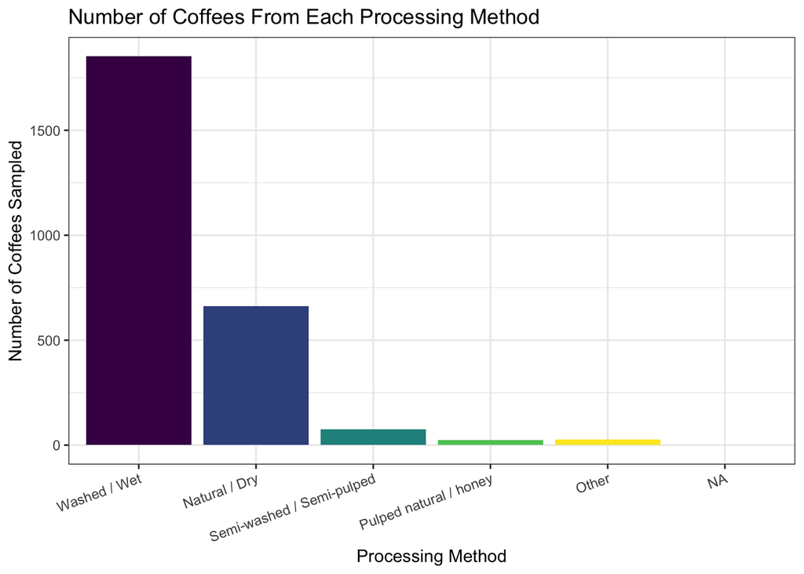

```r
ggplot(data = coffee_ratings,
       aes(x = processing_method,
           fill = processing_method)) +
  geom_bar() +
  scale_fill_viridis_d() +
  labs(
    title = "Number of Coffees From Each Processing Method",
    x = "Processing Method",
    y = "Number of Coffees Sampled"
  ) +
  theme_bw() +
  theme(legend.position = "none",
        axis.text.x = element_text(angle = 20,hjust=1))
```

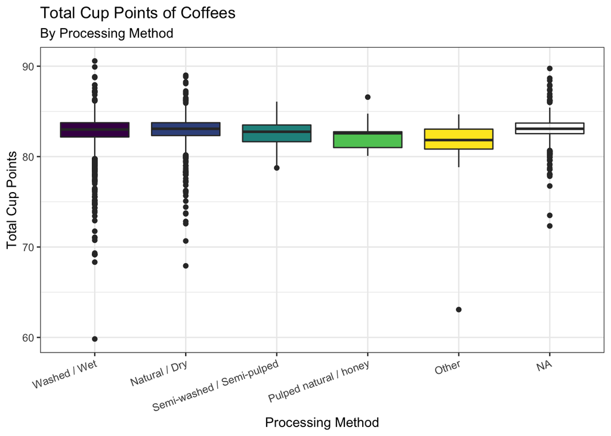

```r
ggplot(data = (coffee_ratings %>% filter(total_cup_points > 0)), # I removed an outlier
       aes(x = processing_method,
           y = total_cup_points,
           fill = processing_method)) +
  geom_boxplot() +
  scale_fill_viridis_d() +
  labs(
    title = "Total Cup Points of Coffees",
    subtitle = "By Processing Method",
    x = "Processing Method",
    y = "Total Cup Points"
  ) +
  theme_bw() +
  theme(legend.position = "none",
        axis.text.x = element_text(angle = 20,hjust=1))
```

- Looking at the boxplot above, there does not appear to be a significant difference in median total cup points across the different processing methods. That being said, the range of total cup points is much wider for washed/wet as compared to semi-washed/semi-pulped or pulped natural/honey. This could partly be due to a smaller sample size in the latter methods.